# Identifying spatial patterns the Greater Golden Horseshoe area, Ontario, Canada

Bruno Dias dos Santos

2023-12-13

## Introduction

This notebook is a component of the GEO712 course’s final project at the School of Earth, Environment & Society of McMaster University. The main objective of the final project is to analyze and compare job accessibility levels across different spatial patterns, focusing on the Greater Golden Horseshoe area (GGH) in Ontario, Canada.

Within this notebook, we present a methodology to perform a Principal Component Analysis (PCA) and identify clusters through an unsupervised classification. The input files for this notebook include:

- Hexagonal grid_(grid_with_all_attributes.shp.shp)_: A cell grid comprised of hexagons with an area of 500 m² with all attributes, obtained after running the notebook *1a_features_extraction.qmd*.
- Local Municipality Boundaries: Shapefile defining the study area’s boundaries.

The output from this notebook includes shapefiles containing the features and the final classification in the cell grid.

## R Markdown

Load R libraries used in the notebook:

```r
library(sf)  # To read shapefiles *only*
```

```r
library(ggplot2) # To plot maps *only*
library(here) # To insert the correct folder to save the pictures in
```

Reading the cell grid and creating a sf DataFrame.

```r
cell_grid <- st_read("vectors\\output\\grid_with_all_attributes.shp")
```

Visualizing the grip in a map format:

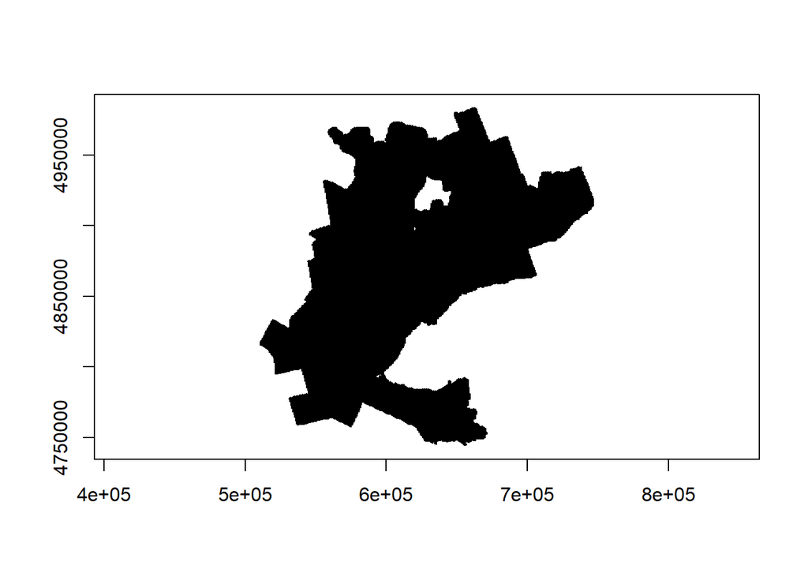

```r
plot(st_geometry(cell_grid), axes = TRUE)
```

Visualizing the first five rows of the dataset:

```r
head(cell_grid,5)
```

```
## Simple feature collection with 5 features and 192 fields
## Geometry type: POLYGON
## Dimension:     XY
## Bounding box:  xmin: 612580 ymin: 4885903 xmax: 613457.3 ymax: 4890462
## Projected CRS: NAD83 / UTM zone 17N
##      id BP_min BP_max    BP_mean BP_sum    BP_std BP_median BP_majorit HE_min
## 1 48948      0     71  0.3736480   1140  4.068330         0          0      0
## 2 48951      0     65  0.4886585   1508  4.231058         0          0      0
## 3 48950      0     88  0.2356604    719  3.389186         0          0      0
## 4 48953      0     92 14.2774716  44046 20.011929         1          0      0
## 5 48952      0     56  0.2222222    678  2.896066         0          0      0
##     HE_max    HE_mean    HE_sum    HE_std HE_median HE_majorit VO_min VO_max
## 1 2.500000 0.31250000  10.00000 0.8267973  0.000000        0.0      0   3108
## 2 2.500000 0.64516129  20.00000 1.0939242  0.000000        0.0      0   2670
## 3 2.500000 0.08064516   2.50000 0.4417117  0.000000        0.0      0     15
```

[output cut: 152 more lines]

Obtaining the name of the columns of the dataset:

```r
names(cell_grid)
```

```
##   [1] "id"         "BP_min"     "BP_max"     "BP_mean"    "BP_sum"
##   [6] "BP_std"     "BP_median"  "BP_majorit" "HE_min"     "HE_max"
##  [11] "HE_mean"    "HE_sum"     "HE_std"     "HE_median"  "HE_majorit"
##  [16] "VO_min"     "VO_max"     "VO_mean"    "VO_sum"     "VO_std"
##  [21] "VO_median"  "VO_majorit" "NRC"        "RES"        "COM"
##  [26] "TR_min"     "TR_max"     "TR_mean"    "TR_sum"     "TR_std"
##  [31] "TR_median"  "TR_majorit" "CR_min"     "CR_max"     "CR_mean"
##  [36] "CR_sum"     "CR_std"     "CR_median"  "CR_majorit" "GR_min"
##  [41] "GR_max"     "GR_mean"    "GR_sum"     "GR_std"     "GR_median"
##  [46] "GR_majorit" "WA_min"     "WA_max"     "WA_mean"    "WA_sum"
##  [51] "WA_std"     "WA_median"  "WA_majorit" "SH_min"     "SH_max"
##  [56] "SH_mean"    "SH_sum"     "SH_std"     "SH_median"  "SH_majorit"
##  [61] "SI_mean"    "SI_sum"     "SI_min"     "SI_max"     "SI_std"
##  [66] "LE_mean"    "LE_sum"     "LE_min"     "LE_max"     "LE_std"
##  [71] "NRo"        "NIn"        "DInBP"      "DInRo"      "NM_BP_min"
```

[output cut: 24 more lines]

Summarizing statistics of the data:

```r
summary(cell_grid)
```

```
##        id             BP_min             BP_max          BP_mean
##  Min.   :   219   Min.   :0.000000   Min.   :  0.00   Min.   : 0.00000
##  1st Qu.: 32507   1st Qu.:0.000000   1st Qu.: 32.00   1st Qu.: 0.05408
##  Median : 49259   Median :0.000000   Median : 70.00   Median : 0.51669
##  Mean   : 51799   Mean   :0.000205   Mean   : 58.67   Mean   : 3.58676
##  3rd Qu.: 69560   3rd Qu.:0.000000   3rd Qu.: 86.00   3rd Qu.: 1.68840
##  Max.   :112861   Max.   :4.000000   Max.   :100.00   Max.   :59.16526
##      BP_sum           BP_std         BP_median       BP_majorit
##  Min.   :     0   Min.   : 0.000   Min.   : 0.00   Min.   :  0.000
##  1st Qu.:   166   1st Qu.: 1.018   1st Qu.: 0.00   1st Qu.:  0.000
##  Median :  1586   Median : 4.225   Median : 0.00   Median :  0.000
##  Mean   : 11010   Mean   : 6.544   Mean   : 1.83   Mean   :  0.267
##  3rd Qu.:  5184   3rd Qu.: 8.122   3rd Qu.: 0.00   3rd Qu.:  0.000
##  Max.   :182584   Max.   :41.622   Max.   :74.00   Max.   :100.000
##      HE_min            HE_max          HE_mean             HE_sum
##  Min.   : 0.0000   Min.   : 0.000   Min.   : 0.00000   Min.   :   0.00
##  1st Qu.: 0.0000   1st Qu.: 2.500   1st Qu.: 0.08333   1st Qu.:   2.50
##  Median : 0.0000   Median : 2.500   Median : 0.41667   Median :  12.50
##  Mean   : 0.3087   Mean   : 3.174   Mean   : 1.23394   Mean   :  37.87
##  3rd Qu.: 0.0000   3rd Qu.: 2.500   3rd Qu.: 0.96774   3rd Qu.:  30.00
##  Max.   :31.0968   Max.   :68.272   Max.   :48.72396   Max.   :1510.44
##      HE_std          HE_median         HE_majorit          VO_min
##  Min.   : 0.0000   Min.   : 0.0000   Min.   : 0.0000   Min.   :    0.0
##  1st Qu.: 0.4488   1st Qu.: 0.0000   1st Qu.: 0.0000   1st Qu.:    0.0
##  Median : 0.9195   Median : 0.0000   Median : 0.0000   Median :    0.0
##  Mean   : 0.9299   Mean   : 0.9757   Mean   : 0.4402   Mean   :  216.3
##  3rd Qu.: 1.1874   3rd Qu.: 0.0000   3rd Qu.: 0.0000   3rd Qu.:    0.0
##  Max.   :14.9907   Max.   :51.4899   Max.   :31.0968   Max.   :65697.0
##      VO_max          VO_mean              VO_sum            VO_std
##  Min.   :     0   Min.   :     0.00   Min.   :      0   Min.   :     0.00
##  1st Qu.:   215   1st Qu.:     8.69   1st Qu.:    266   1st Qu.:    39.79
##  Median :  1828   Median :   125.97   Median :   3862   Median :   398.74
##  Mean   :  8911   Mean   :  2603.08   Mean   :  79902   Mean   :  2167.89
##  3rd Qu.:  4970   3rd Qu.:   448.39   3rd Qu.:  13724   3rd Qu.:  1096.13
##  Max.   :612601   Max.   :210290.97   Max.   :6519020   Max.   :108687.11
##    VO_median        VO_majorit           NRC              RES
##  Min.   :     0   Min.   :    0.0   Min.   :0.0000   Min.   :0.000000
##  1st Qu.:     0   1st Qu.:    0.0   1st Qu.:0.9034   1st Qu.:0.005572
##  Median :     0   Median :    0.0   Median :0.9663   Median :0.033432
##  Mean   :  2106   Mean   :  230.7   Mean   :0.8725   Mean   :0.116261
```

[output cut: 288 more lines]

```
##  Max.   : 1.00000   Max.   : 1.00000   Max.   : 1.0000   Max.   : 1.000000
##    DNM_SH_mea          DNM_SH_sum          DNM_SH_std         DNM_SH_med
##  Min.   :-1.000000   Min.   :-1.000000   Min.   :-1.00000   Min.   :-1.0000
##  1st Qu.:-0.329018   1st Qu.:-0.329289   1st Qu.:-0.18529   1st Qu.:-0.7600
##  Median :-0.009695   Median :-0.009799   Median :-0.01175   Median : 0.0000
##  Mean   :-0.045068   Mean   :-0.045329   Mean   :-0.03313   Mean   :-0.1019
##  3rd Qu.: 0.259744   3rd Qu.: 0.259619   3rd Qu.: 0.15642   3rd Qu.: 0.3333
##  Max.   : 1.000000   Max.   : 1.000000   Max.   : 1.00000   Max.   : 1.0000
##    DNM_SH_maj               geometry
##  Min.   :-1.0000   POLYGON      :53609
##  1st Qu.:-1.0000   epsg:26917   :    0
##  Median : 0.0000   +proj=utm ...:    0
##  Mean   :-0.2361
##  3rd Qu.: 0.3521
##  Max.   : 1.0000
```

Plotting a map of the data set by the variable “BP_mean”, which means the average value of the “Built-up area” identified in the satellite images within the cell.

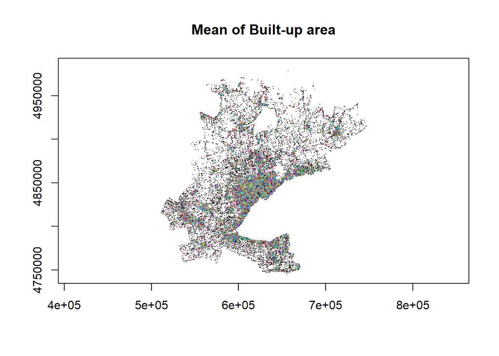

```r
plot(st_geometry(cell_grid), col = cell_grid$BP_mean, axes = TRUE, border = NA, main = "Mean of Built-up area")
```

The R built-in functions make difficult to visualize the difference of the variable between the cells. Because of this, we will use the ggplot library to plot a new map.

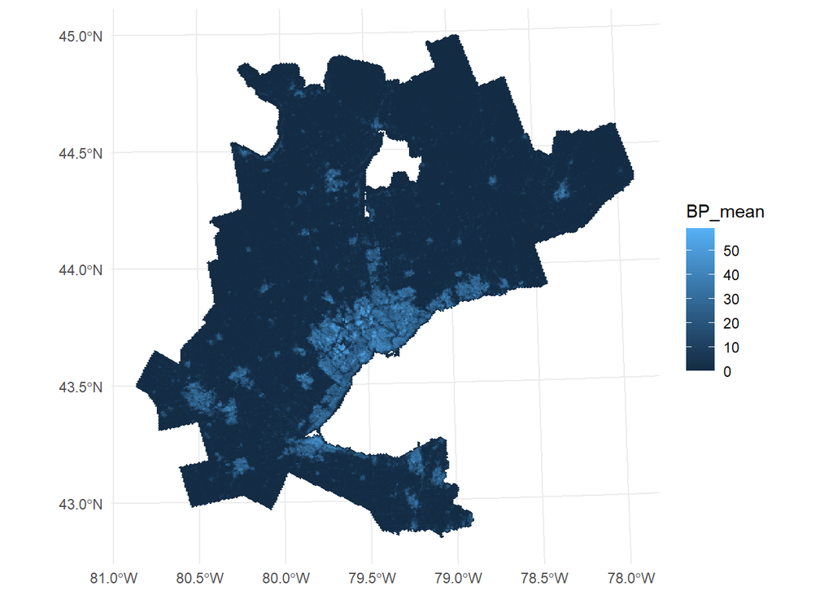

```r
ggplot() +
  geom_sf(data = cell_grid, aes(fill = BP_mean), color = NA) +
  theme_minimal()
```

Now we can see the differences in the built-up area within the study area.

Checking the total number of rows in the dataset.

```r
nrow(cell_grid)
```

```
## [1] 53609
```

Excluding possible missing values and rechecking the total number of rows.

```r
cell_grid <- na.omit(cell_grid)
nrow(cell_grid)
```

```
## [1] 53609
```

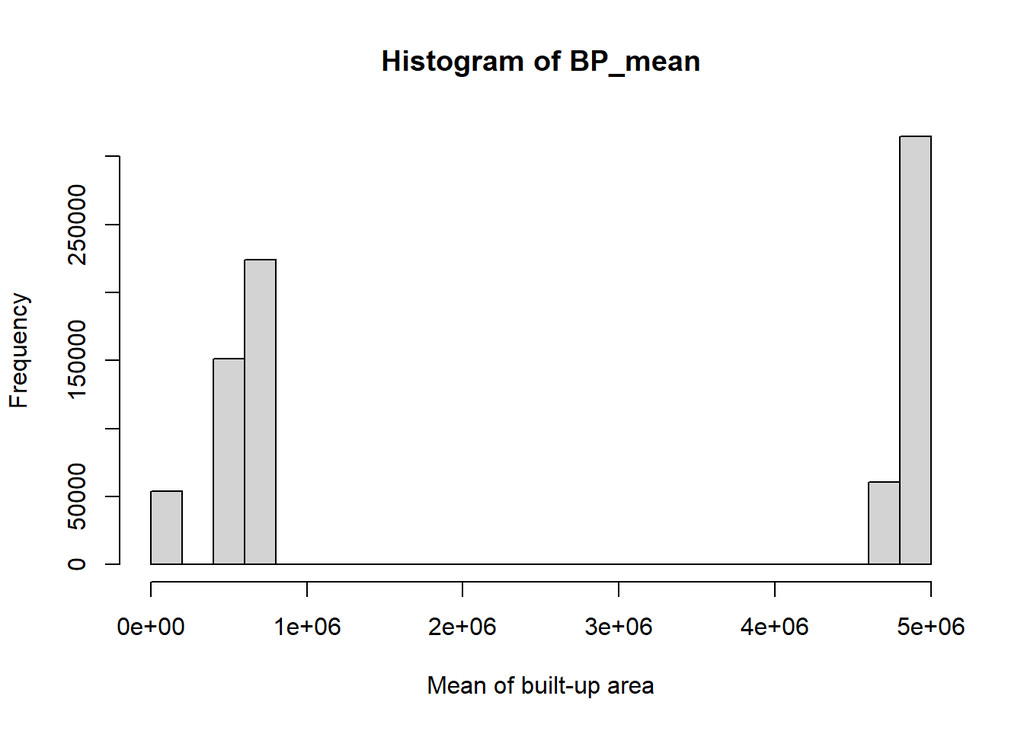

```r
hist(as.numeric(unlist(cell_grid["BP_mean"])), xlab = "Mean of built-up area", ylab = "Frequency", main = "Histogram of BP_mean")
```

Understanding intraurban differences is crucial for comprehending variations in accessibility levels. With the dataset at hand, we selected cells based on a threshold value for the presence of built-up areas. Hexagons with less than 10% of the sum of residential and commercial buildings were excluded from the analysis. This criterion was implemented to enhance the clustering process. Without this restriction, the clustering algorithm tended to create numerous clusters outside the urban area, without showing the intraurban differences.

Now, plotting a histogram of the filtered data.

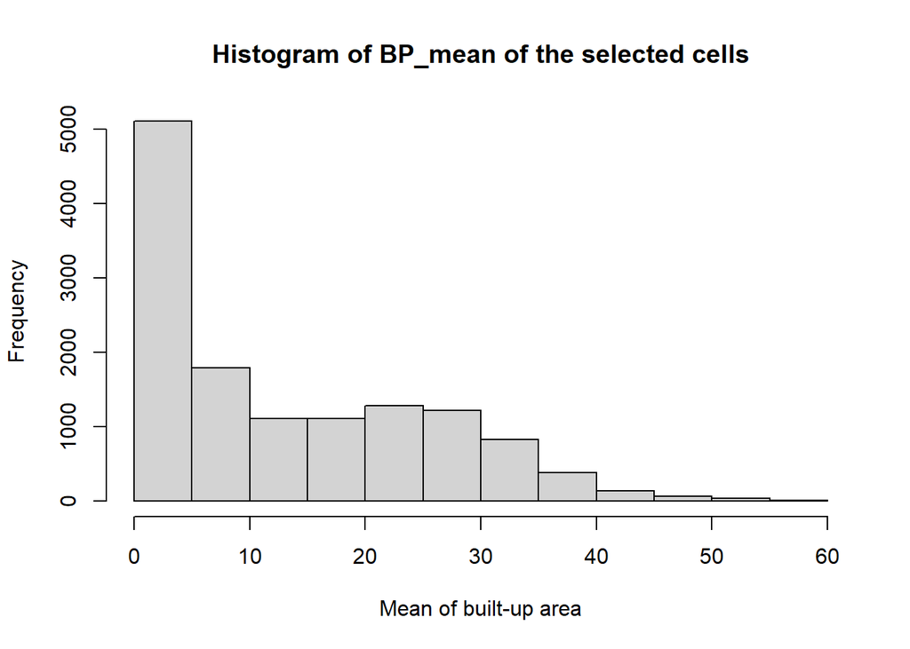

```r
hist(cell_grid[(cell_grid$RES + cell_grid$COM) >= 0.1, ]$BP_mean, xlab = "Mean of built-up area", ylab = "Frequency", main = "Histogram of BP_mean of the selected cells")
```

Creating a new dataset with the selected data.

```r
subset <- as.data.frame(cell_grid[(cell_grid$RES + cell_grid$COM) >= 0.1, ])
```

Creating a dataframe, excluding the variables ‘id’ and ‘geometry’ to perform the PCA Analysis.

```r
df <- subset[,2:(length(subset)-1)]
```

Visualization of the correlation matrix of the variables related to the built-up area.

```r
corr_mv <- cor(df[,1:7])
corr_mv
```

```
##                 BP_min     BP_max    BP_mean     BP_sum      BP_std  BP_median
## BP_min     1.000000000 0.00530422 0.03796515 0.03785699 0.002761638 0.04404045
## BP_max     0.005304220 1.00000000 0.59986880 0.59988330 0.717406643 0.46694714
## BP_mean    0.037965151 0.59986880 1.00000000 0.99996448 0.867710518 0.93209531
## BP_sum     0.037856993 0.59988330 0.99996448 1.00000000 0.867669868 0.93210209
## BP_std     0.002761638 0.71740664 0.86771052 0.86766987 1.000000000 0.65434669
## BP_median  0.044040449 0.46694714 0.93209531 0.93210209 0.654346694 1.00000000
## BP_majorit 0.043792015 0.09260502 0.30810526 0.30818070 0.219154271 0.34026619
##            BP_majorit
## BP_min     0.04379202
## BP_max     0.09260502
## BP_mean    0.30810526
## BP_sum     0.30818070
## BP_std     0.21915427
## BP_median  0.34026619
## BP_majorit 1.00000000
```

We can see that some variables have a high correlation. For instance, BP_mean and BP_std have a correlation of around 0.87. In fact, the entire data set has variables with a high level of linear correlation. For this reason, we will apply a PCA analysis to reduce the dimensionality of the data.

## Principal Component Analysis

Creating the PCA, normalizing the data.

```r
#pca_out <- prcomp(df, center = TRUE, scale = TRUE)
```

There is an error in our data set, because one (or more) of our variables has a constant value, making it impossible to scale the z score. The code above will remove columns with constant values:

```r
remove <- c()

# Evaluating if the variance of each column is equal to zero
for(i in 1:length(names(df))){
  if(var(df[,i])==0){
    remove <- append(remove, i)
  }
}

# Removing columns with constant value of the dataset
df <- subset(df, select = -remove)
```

Conting the number of variables of the new dataset.

```r
ncol(df)
```

```
## [1] 190
```

visualizing the index of the column that has constant value.

```r
remove
```

```
## [1] 46
```

Performing a new PCA analysis.

```r
pca_out <- prcomp(df, center = TRUE, scale = TRUE)
```

Visualizing the summary of our PCA.

```r
summary(pca_out)
```

```
## Importance of components:
##                           PC1     PC2     PC3     PC4     PC5     PC6     PC7
## Standard deviation     8.2111 4.16468 3.45167 3.16079 2.84996 2.48955 2.28528
## Proportion of Variance 0.3549 0.09129 0.06271 0.05258 0.04275 0.03262 0.02749
## Cumulative Proportion  0.3549 0.44614 0.50885 0.56143 0.60418 0.63680 0.66429
##                            PC8     PC9    PC10    PC11    PC12    PC13    PC14
## Standard deviation     1.94482 1.90650 1.79954 1.61426 1.59883 1.54558 1.42736
## Proportion of Variance 0.01991 0.01913 0.01704 0.01371 0.01345 0.01257 0.01072
## Cumulative Proportion  0.68420 0.70333 0.72037 0.73408 0.74754 0.76011 0.77083
##                          PC15    PC16    PC17    PC18    PC19    PC20    PC21
## Standard deviation     1.3921 1.34694 1.30589 1.26910 1.24678 1.18874 1.17847
## Proportion of Variance 0.0102 0.00955 0.00898 0.00848 0.00818 0.00744 0.00731
## Cumulative Proportion  0.7810 0.79058 0.79956 0.80803 0.81622 0.82365 0.83096
##                           PC22    PC23    PC24    PC25    PC26    PC27    PC28
## Standard deviation     1.15912 1.09157 1.07993 1.05830 1.00924 0.99719 0.97848
## Proportion of Variance 0.00707 0.00627 0.00614 0.00589 0.00536 0.00523 0.00504
## Cumulative Proportion  0.83803 0.84430 0.85044 0.85634 0.86170 0.86693 0.87197
##                           PC29    PC30    PC31    PC32    PC33    PC34    PC35
## Standard deviation     0.96054 0.95182 0.93725 0.92036 0.90767 0.88789 0.84535
## Proportion of Variance 0.00486 0.00477 0.00462 0.00446 0.00434 0.00415 0.00376
## Cumulative Proportion  0.87683 0.88160 0.88622 0.89068 0.89501 0.89916 0.90292
##                           PC36    PC37    PC38    PC39    PC40    PC41    PC42
## Standard deviation     0.81302 0.80893 0.79557 0.78227 0.76220 0.74778 0.72614
## Proportion of Variance 0.00348 0.00344 0.00333 0.00322 0.00306 0.00294 0.00278
## Cumulative Proportion  0.90640 0.90985 0.91318 0.91640 0.91946 0.92240 0.92517
##                           PC43    PC44   PC45    PC46    PC47    PC48    PC49
## Standard deviation     0.71164 0.70110 0.6898 0.67043 0.66618 0.65879 0.63910
## Proportion of Variance 0.00267 0.00259 0.0025 0.00237 0.00234 0.00228 0.00215
## Cumulative Proportion  0.92784 0.93043 0.9329 0.93530 0.93763 0.93992 0.94207
##                           PC50    PC51    PC52    PC53    PC54    PC55    PC56
## Standard deviation     0.62767 0.61914 0.60513 0.59489 0.58254 0.57328 0.56035
## Proportion of Variance 0.00207 0.00202 0.00193 0.00186 0.00179 0.00173 0.00165
## Cumulative Proportion  0.94414 0.94616 0.94808 0.94995 0.95173 0.95346 0.95512
##                           PC57    PC58    PC59    PC60    PC61    PC62   PC63
## Standard deviation     0.55293 0.54941 0.54038 0.51946 0.51129 0.50600 0.4968
## Proportion of Variance 0.00161 0.00159 0.00154 0.00142 0.00138 0.00135 0.0013
## Cumulative Proportion  0.95672 0.95831 0.95985 0.96127 0.96265 0.96399 0.9653
##                           PC64    PC65   PC66    PC67    PC68   PC69    PC70
## Standard deviation     0.49345 0.48457 0.4765 0.47026 0.46684 0.4570 0.44782
## Proportion of Variance 0.00128 0.00124 0.0012 0.00116 0.00115 0.0011 0.00106
```

[output cut: 58 more lines]

```
## Standard deviation     0.02673 0.02399 0.01952 0.01872 0.01685 0.01662 0.01398
## Proportion of Variance 0.00000 0.00000 0.00000 0.00000 0.00000 0.00000 0.00000
## Cumulative Proportion  0.99999 0.99999 0.99999 0.99999 0.99999 1.00000 1.00000
##                         PC176    PC177    PC178    PC179    PC180    PC181
## Standard deviation     0.0125 0.009228 0.007166 0.006786 0.006113 0.006047
## Proportion of Variance 0.0000 0.000000 0.000000 0.000000 0.000000 0.000000
## Cumulative Proportion  1.0000 1.000000 1.000000 1.000000 1.000000 1.000000
##                           PC182    PC183    PC184  PC185    PC186    PC187
## Standard deviation     0.005935 0.004451 0.004023 0.0032 0.002574 0.001987
## Proportion of Variance 0.000000 0.000000 0.000000 0.0000 0.000000 0.000000
## Cumulative Proportion  1.000000 1.000000 1.000000 1.0000 1.000000 1.000000
##                           PC188     PC189     PC190
## Standard deviation     0.001398 5.129e-15 1.982e-15
## Proportion of Variance 0.000000 0.000e+00 0.000e+00
## Cumulative Proportion  1.000000 1.000e+00 1.000e+00
```

We can see that the first component explains 35% of the variability in our data; the second component explains 9%; and so on. The first thirty-five components accumulate 90% of the variability of the original dataset.

Plotting a graph to visualizing the cumulative proportion of variance.

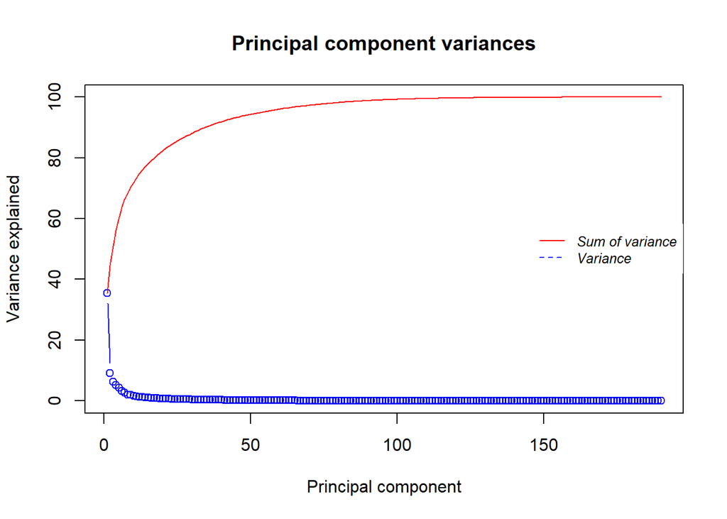

```r
# Calculating the proportion of variance explained by each principal component
var <- pca_out$sdev^2 / sum(pca_out$sdev^2)

# Converting variance to percentages
var <- var * 100

# Creating a variable to hold the cumulative sum of variance
var_sum <- var

# Calculating the cumulative sum of variance
for (i in 2:length(var_sum)) {
var_sum[i] <- var_sum[i] + var_sum[i - 1]
}

# Creating a plot of principal component variances
plot(c(1:length(var)), var, xlab="Principal component",ylab="Variance explained", main = "Principal component variances", col = "blue", type = "b",ylim = c(0, max(var,var_sum)))

# Adding a line plot for the cumulative sum of variance
lines(c(1:length(var)), var_sum, col = "red")

# Adding a legend
legend("right", legend=c("Sum of variance", "Variance"),
col=c("red", "blue"), lty=1:2, cex=0.8,
text.font=3, box.lty=0, bg=)
```

Plotting a biplot graph.

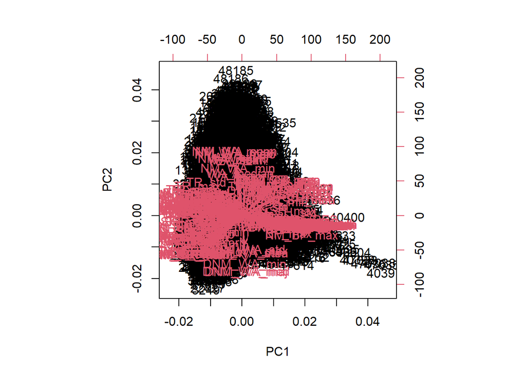

```r
biplot(pca_out)
```

Due to the large number of variables, it is difficult to see a pattern in the biplot above.

Selecting the components where the cumulative variation of the original dataset is 90%.

```r
principalDf <- pca_out$x[,1:35]
```

Obtaining the loadings of the selected components.

```r
loadings <- as.data.frame(pca_out$rotation[,1:35])
```

Visualizing the top 3 absolute loadings for each PC.

```r
set.seed(51)

get_top_loadings <- function(pc_vector) {
  top_indices <- order(abs(pc_vector), decreasing = TRUE)[1:3]
  return(top_indices)
}

top_indices_list <- apply(loadings[,1:4], 2, get_top_loadings)
```

Visualizing the indexes of the variables with the highest loadings in the first four principal components.

```r
top_indices_list
```

```
##      PC1 PC2 PC3 PC4
## [1,]  76 120 134 158
## [2,]  75 121 135 159
## [3,]  94 123 154 157
```

Selecting the 3 principal loadings for the first four principal components.

```r
merged_column <- unique(c(top_indices_list))
round(loadings[merged_column,1:4],3)
```

```
##               PC1    PC2    PC3    PC4
## NM_BP_sum   0.115 -0.029 -0.029  0.020
## NM_BP_mean  0.115 -0.029 -0.029  0.020
## NM_NRC     -0.114  0.021  0.014 -0.034
## NM_WA_mean -0.011  0.194 -0.023 -0.111
## NM_WA_sum  -0.011  0.194 -0.023 -0.111
## NM_WA_medi -0.011  0.188 -0.025 -0.111
## DNM_BP_mea -0.062  0.027 -0.228  0.040
## DNM_BP_sum -0.062  0.027 -0.228  0.040
## DNM_RES    -0.060  0.024 -0.226  0.030
## DNM_TR_mea  0.074 -0.037  0.053 -0.161
## DNM_TR_sum  0.074 -0.037  0.053 -0.161
## DNM_TR_max  0.061 -0.034  0.018 -0.161
```

Across all components, variables related to neighbor relations demonstrated the most substantial loadings. Component 1 exhibits higher absolute loadings in the neighbor mean of built-up type variables, predominantly associated with more densely built-up areas in the study area; Component 2 displays higher absolute loadings in variables related to the fraction of water on neighboring cells, indicating a correlation with waterfront areas; Component 3 focuses on the presence of built-up areas and residential use in neighboring cells; and Component 4 correlates with the presence of trees in neighboring cells.

## Clustering Analysis

Creating the clustering model. After several experiments and visual analyses, we settled on six final clusters, considering the best trade-off between identifying meaningful clusters and their quantity.

```r
set.seed(51)
clustering <- kmeans(principalDf, centers=6, iter.max = 500, algorithm = "Lloyd")
```

Visualizing the amount of features in each group.

```r
clustering$size
```

```
## [1] 2240 2322 3669 1280  808 2778
```

Adding the cluster classification to the PC dataframe

```r
principalDf <- as.data.frame(principalDf)
principalDf$Cluster <- clustering$cluster
principalDf$id <- subset$id
```

```r
principalDf
```

```
##                 PC1           PC2           PC3           PC4           PC5
## 4       4.086752043  -0.644129427   3.450142496  -2.168918783 -6.899699e-01
## 6       9.067502737  -0.718083226   1.061390208  -1.790107865 -2.653591e+00
## 7       8.651923322  -1.831076936  -0.108278853  -1.236664662 -1.113959e-01
## 8      -3.528445625  -5.475315634   0.038700338  -4.092257775 -5.231210e-02
## 9       4.156636556  -3.986314483  -0.227258779   1.485403894 -3.694192e+00
## 10     -7.368675095  -4.677740602   3.473976091  -3.327654636 -2.320348e-01
## 22     -9.297246318  -9.391083124   1.504871659  -0.396825350 -5.007826e+00
## 24    -10.156272150  -6.206653614  -5.651770299  -4.864534534  1.664489e+00
## 26     -8.822313090  -4.361123364  -2.366638368  -3.404766241  6.276753e-01
## 30     -3.730834767   8.500312764   0.732319807  -2.172625418  1.792947e+00
## 39     -8.917840175  -3.014390029  -3.813615182  -3.245119373  2.537200e+00
## 41     -7.170516756  -5.388944221   2.202454981  -6.098399837  1.865652e+00
## 43     -7.263435325  -4.602527677   0.654051151   2.224459988 -1.526133e+00
## 50     -6.635292964  -4.158938312   3.849550567  -2.032160690 -1.398777e-01
```

[output cut: 21610 more lines]

Bringing these new variables to the grid dataset.

```r
grid_with_all_attributes <- merge(cell_grid, principalDf, by.x = 'id', by.y = 'id', all.x=TRUE)
```

Transforming this dataset into a sf dataset.

```r
grid_with_all_attributes <- st_as_sf(grid_with_all_attributes, crs = st_crs(cell_grid))
```

Creating a dataset with the classification.

```r
grid_classified <- grid_with_all_attributes[,c("id","Cluster")]
```

Plotting a map of the spatial patterns.

```r
boundaries <- sf::st_read("vectors//boundaries//tts06_pd_83.shp")
```

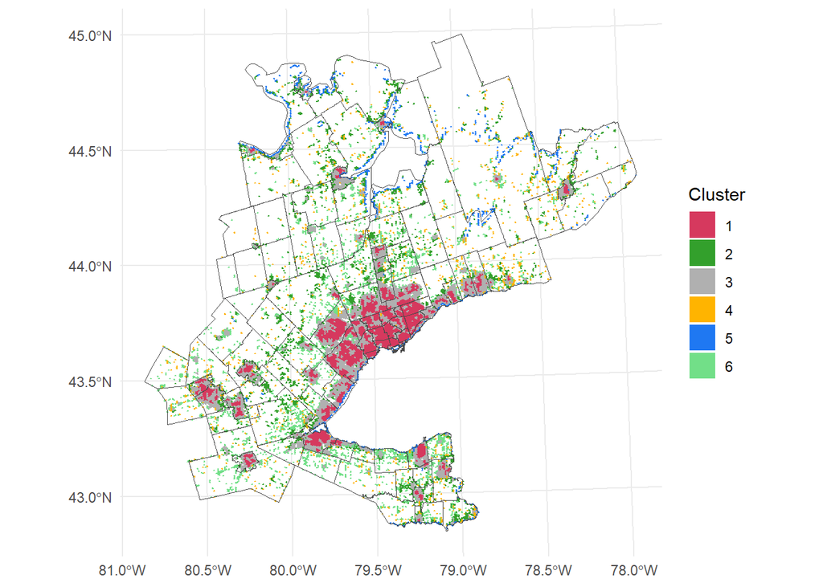

```r
custom_colors <- c("#d6395e", "#33a02c", "#b0b0b0", "#ffb400", "#1f78f2", "#72df88")

map <- ggplot() +
  geom_sf(data = grid_classified[!(is.na(grid_classified$Cluster)),], aes(fill = as.factor(Cluster)), color = NA) +
  geom_sf(data = boundaries, color = "#4a4a4a", fill = NA) +
  labs(fill = "Cluster") +
  scale_fill_manual(values = custom_colors) +
  theme_minimal()

map
```

Selection of a variable to evaluate the difference between the clusters.

[figure not shown]

```r
par(mfrow = c(2, 4))

# Boxplot 1: Built-up Mean
boxplot(BP_mean ~ Cluster, data = grid_with_all_attributes[!(is.na(grid_with_all_attributes$Cluster)),], main = "Built-up Mean", outline = FALSE)

# Boxplot 2: Tree Mean
boxplot(TR_mean ~ Cluster, data = grid_with_all_attributes[!(is.na(grid_with_all_attributes$Cluster)),], main = "Tree Mean", outline = FALSE)

# Boxplot 3: % Residential
boxplot(RES ~ Cluster, data = grid_with_all_attributes[!(is.na(grid_with_all_attributes$Cluster)),], main = "% Residential", outline = FALSE)

# Boxplot 4: "% Commerce"
boxplot(COM ~ Cluster, data = grid_with_all_attributes[!(is.na(grid_with_all_attributes$Cluster)),],main = "% Commerce", outline = FALSE)

# Boxplot 5: Grass Mean
boxplot(GR_mean ~ Cluster, data = grid_with_all_attributes[!(is.na(grid_with_all_attributes$Cluster)),], main = "Grass Mean", outline = FALSE)

# Boxplot 6: Crop Mean
boxplot(CR_mean ~ Cluster, data = grid_with_all_attributes[!(is.na(grid_with_all_attributes$Cluster)),], main = "Crop Mean", outline = FALSE)

# Boxplot 7: Water Mean
boxplot(DInRo ~ Cluster, data = grid_with_all_attributes[!(is.na(grid_with_all_attributes$Cluster)),], main = "Water Mean", outline = FALSE)

# Boxplot 8: wa_ac_emp
boxplot(DInBP ~ Cluster, data = grid_with_all_attributes[!(is.na(grid_with_all_attributes$Cluster)),], main = "Intersections by BP area", outline = FALSE)
```

```r
par(mfrow = c(1, 1))
```

## Data export

Saving the cluster’s figure.

```r
ggsave(here::here("figures", "spatial_patterns_map.png"), map, width = 10, height = 8, units = "cm")
```

Exporting the classification dataset.

```r
st_write(grid_classified, "vectors\\output\\grid_classified.shp", append=FALSE)
```

```
## Deleting layer `grid_classified' using driver `ESRI Shapefile'
## Writing layer `grid_classified' to data source
##   `vectors\output\grid_classified.shp' using driver `ESRI Shapefile'
## Writing 53609 features with 2 fields and geometry type Polygon.
```

Dataset export with all attributes, selected principal components and clustering result.

```r
st_write(grid_with_all_attributes, "vectors\\output\\grid_with_attributes_35pcas_cluster.shp", append=FALSE)
```

```
## Writing layer `grid_with_attributes_35pcas_cluster' to data source
##   `vectors\output\grid_with_attributes_35pcas_cluster.shp' using driver `ESRI Shapefile'
## Writing 53609 features with 228 fields and geometry type Polygon.
```